# AQUASTAT

Anna Boser

2023-12-11

```r
aquastat = fread(here("data/AQUASTAT Dissemination System.csv"), header = TRUE)

long_data <- pivot_longer(aquastat, cols = 5:ncol(aquastat), names_to = "Year", values_to = "Value", names_prefix = '"')
wide_data <- select(long_data, "Country", "Variable", "Year", "Value") %>% pivot_wider(names_from = "Variable", values_from = "Value")
african_countries <- c("Algeria", "Angola", "Benin", "Botswana", "Burkina Faso", "Burundi", "Cabo Verde", "Cameroon", "Central African Republic", "Chad", "Comoros", "Congo, Democratic Republic of the", "Congo, Republic of the", "Cote d’Ivoire", "Djibouti", "Egypt", "Equatorial Guinea", "Eritrea", "Eswatini", "Ethiopia", "Gabon", "Gambia", "Ghana", "Guinea", "Guinea-Bissau", "Kenya", "Lesotho", "Liberia", "Libya", "Madagascar", "Malawi", "Mali", "Mauritania", "Mauritius", "Morocco", "Mozambique", "Namibia", "Niger", "Nigeria", "Rwanda", "Sao Tome and Principe", "Senegal", "Seychelles", "Sierra Leone", "Somalia", "South Africa", "South Sudan", "Sudan", "Tanzania", "Togo", "Tunisia", "Uganda", "Zambia", "Zimbabwe")

SSA_countries <- c("Angola", "Benin", "Botswana", "Burkina Faso", "Burundi", "Cabo Verde", "Cameroon", "Central African Republic", "Chad", "Comoros", "Congo, Democratic Republic of the", "Congo, Republic of the", "Djibouti", "Equatorial Guinea", "Eritrea", "Eswatini", "Ethiopia", "Gabon", "Gambia", "Ghana", "Guinea", "Guinea-Bissau", "Kenya", "Lesotho", "Liberia", "Madagascar", "Malawi", "Mali", "Mauritania", "Mauritius", "Mozambique", "Namibia", "Niger", "Nigeria", "Rwanda", "Sao Tome and Principe", "Senegal", "Seychelles", "Sierra Leone", "Somalia", "South Africa", "South Sudan", "Sudan", "Tanzania", "Togo", "Uganda", "Zambia", "Zimbabwe")
```

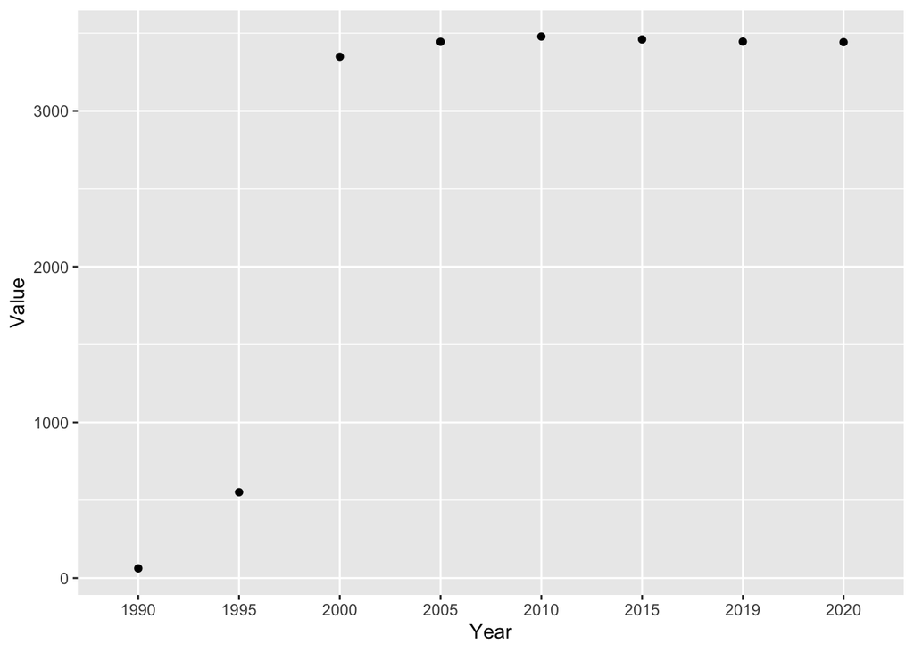

```r
# plot the irrigated area time series for SSA countries
long_data %>%
  filter(Country %in% SSA_countries, Variable == "Area equipped for irrigation: actually irrigated") %>%
  group_by(Year) %>%
  summarize(Value = sum(Value, na.rm = TRUE)) %>%
  ggplot() +
  geom_point(aes(x = Year, y = Value))
```

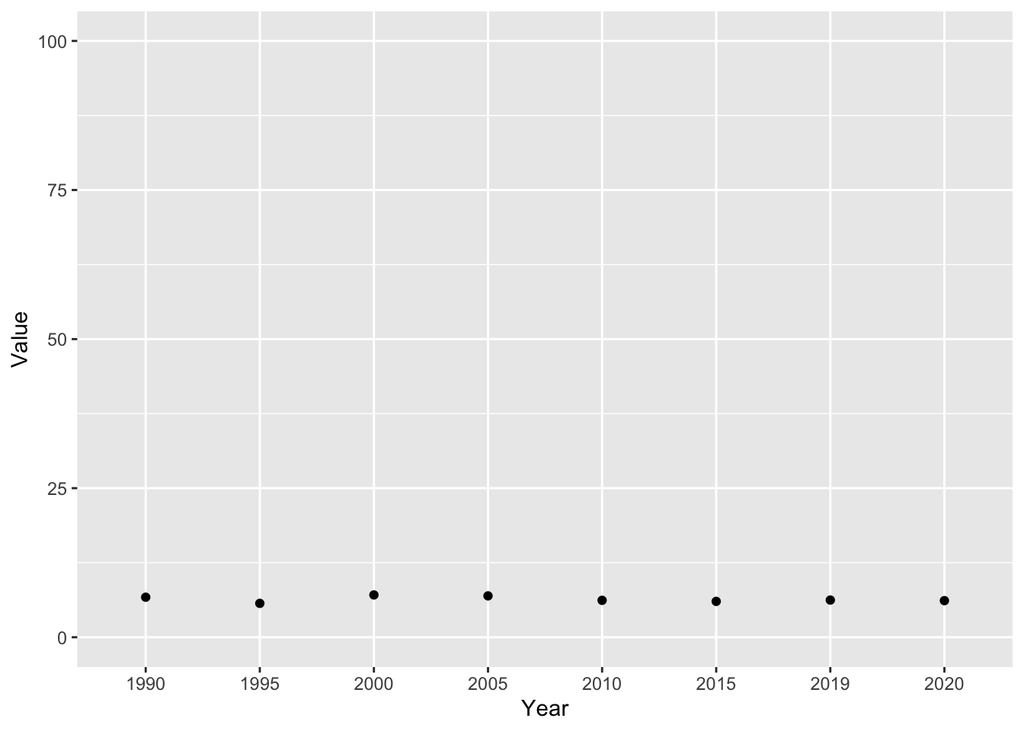

```r
# plot the irrigated percent time series for SSA countries
long_data %>%
  filter(Country %in% SSA_countries, Variable == "% of the cultivated area equipped for irrigation") %>%
  group_by(Year) %>%
  summarize(Value = mean(Value, na.rm = TRUE)) %>%
  ggplot() +
  geom_point(aes(x = Year, y = Value)) +
  ylim(0, 100)
```

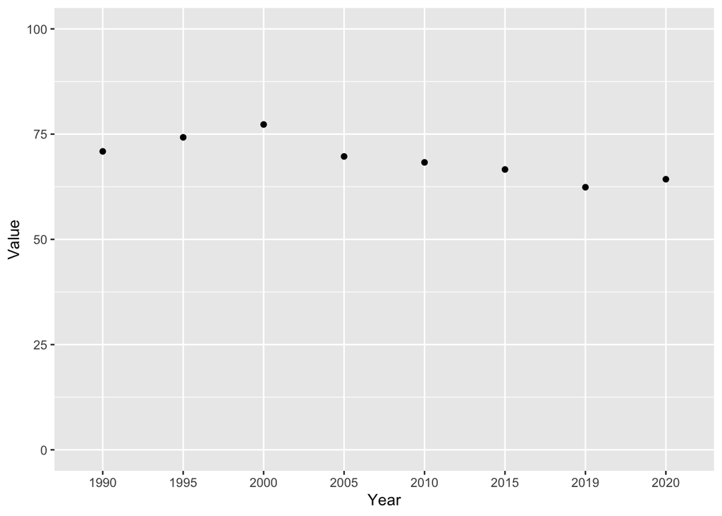

```r
# plot the irrigated percent time series for SSA countries
long_data %>%
  filter(Country %in% SSA_countries, Variable == "% of the area equipped for irrigation actually irrigated") %>%
  group_by(Year) %>%
  summarize(Value = mean(Value, na.rm = TRUE)) %>%
  ggplot() +
  geom_point(aes(x = Year, y = Value)) +
  ylim(0, 100)
```